# APEC 8601: Natural Resource Economics

## 4 Suckerville Fishery

The people of Suckerville harvest the long-nosed sucker fish from Big Sucker Lake. Suckerville residents get utility both from harvesting fish and from the stock of fish in the lake, represented by a utility function $U(h_t, X_t)$, where $h_t$ is fish harvest at time $t$ and $X_t$ is fish stock at time $t$. Assume that $U_h > 0, U_{hh} < 0, U_X > 0, U_{XX} < 0, U_{hX} = 0$, where these expressions represent the first and second derivatives of the utility function with respect to $h$ or $X$. The long-nosed sucker fish has a biological growth function given by $G(X_t)$, with $G(0) = G(K) = 0$, where $K$ is natural carrying capacity, $G(X_t) > 0$ and $G"(X_t) < 0$ for $X_t \in(0, K), G'(X_t) > 0$, for $X_t \in [0, X_{msy}), G'(X_t) < 0$ for $X_t \in (X_{msy}, K)$, where $X_{msy}$ is the maximum sustainable yield stock level. The change in the fish population is given by $X_t=G(X_t)-h_t$. The initial stock of the fish is $X_0 > 0$. The people of Suckerville have a discount rate applied to utility of $\delta > 0$.

1. Write down the dynamic optimization problem where the goal is to maximize the present value of utility from harvest over an infinite time horizon. Please include relevant constraints in the statement of the problem.

**Answer**

Optimal harvesting problem:
$$\begin{aligned}
V(S_0) &= max \int_{0}^{\infty} U(h_t,X_t) e^{-\delta t} dt \\
& \text{subject to} \\
& \dot{X}_t = G(X_t) - h_t \\
& h_t \ge 0; X_t \ge 0; X_0 \ge 0
\end{aligned}$$

2. Write down the current value Hamiltonian and derive the necessary conditions for an optimal path.

**Answer**

Current value Hamiltonian:
$$\tilde{H} = U(h_t, X_t) + \mu_t (G(X_t) - h_t)$$

Necessary conditions for an optimal solution:
$$\begin{aligned}
\frac{\partial \tilde{H}}{\partial h} &= 0 \\
&\Longrightarrow U_h - \mu_t = 0 \\
\frac{\partial \tilde{H}}{\partial S} &= - \dot{\mu}_t + \delta \mu_t \\
& \Longrightarrow U_X + \mu_t G'(X_t)= - \dot{\mu}_t + \delta \mu_t \\
& \qquad \dot{\mu}_t = \mu_t (\delta - G'(X_t)) - U_X \\
\frac{\partial \tilde{H}}{\partial \mu} &= \dot{X}_t \\
&\Longrightarrow G(X_t) - h_t = \dot{X}_t
\end{aligned}$$

3. Solve for conditions that define an optimal steady state.

**Answer**

Differentiate the first condition with respect to $t$ and substitute out $\dot{X}_t, \dot{\mu}_t, \mu_t$:
$$\begin{aligned}
U_{hh} \dot{h}_t - U_{hX} \dot{X}_t &= \dot{\mu}_t \\
U_{hh} \dot{h}_t - U_{hX} \dot{X}_t &= \mu_t (\delta - G'(X_t)) - U_X \\
U_{hh} \dot{h}_t - U_{hX} (G(X_t) - h_t) &= \mu_t (\delta - G'(X_t)) - U_X \\
U_{hh} \dot{h}_t - U_{hX} (G(X_t) - h_t) &= U_h (\delta - G'(X_t)) - U_X \\
\dot{h} &= \frac{U_h(G'(X_t) - \delta) + U_X + U_{hS}(G(X_t) - h_t)}{- U_{hh}}
\end{aligned}$$

At steady state $G(X_t)- h_t = \dot{X}_t = 0$, so the third term in the numerator is zero. Since $U_X >0$, it must be true that $G'(X_t) - \delta < 0$ so that $\dot{h}_t=0$ since $U_h>0$.

4. How does the stock level in the optimal steady state compare to stock level that satisfies the golden rule of growth? Is it greater than, equal, less than, or ambiguous?

**Answer**

When the stock level satisfies the golden rule of growth then the growth rate equals the discount rate: $G'(X_t)=\delta$. Since the steady state requires that $G'(X_t) < \delta$, it must be the case that the stock level in the optimal steady is greater than the stock level that satisfies the golden rule: $X_t^{ss} > X_t^{gr}$.

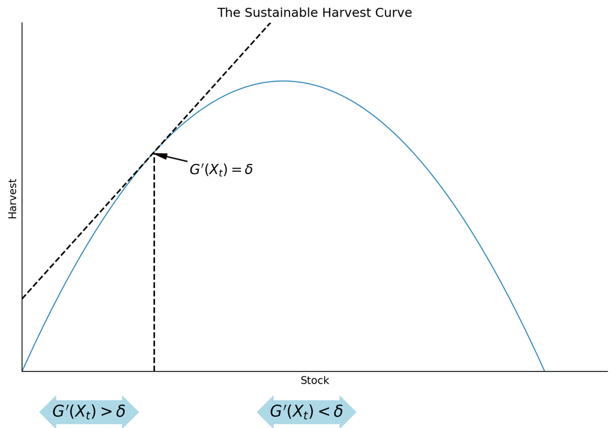

5. How does the stock level in the optimal steady state compare to the maximum sustained yield stock level? Is it greater than, equal, less than, or ambiguous?

**Answer**

At the maximum sustained yield, the growth rate is equal to zero: $G'(X_t)=0$. This means that it is ambiguous compared to the optimal steady state stock level. The optimal steady state require only that $G'(X_t) < \delta$, but this could occur to either side of the maximum sustained yield point.

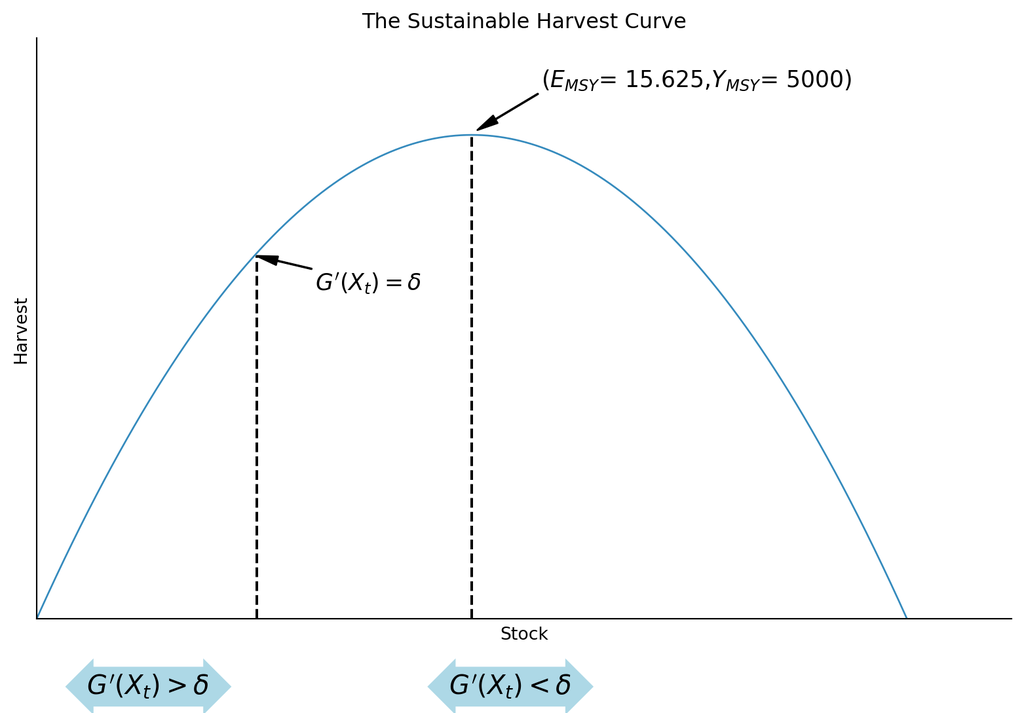

6. Clark (1973) showed that it may be optimal to harvest stock to extinction. Write down conditions that would give rise to optimal extinction and explain the economic logic for your result.

**Answer**

Since $U_h >0$, there are positive returns from harvest. Then we can consider the case where $G'(0)< \delta$. Then $G'(X_t) < \delta$ and $\dot{h}_t<0$ for all $X_t>0$. The only steady state that exists is extinction where $h_t=X_t=0$. The intuition behind this is that the discount rate is so much higher than the growth rate that it is optimal to harvest all the stock and invest that capital elsewhere.

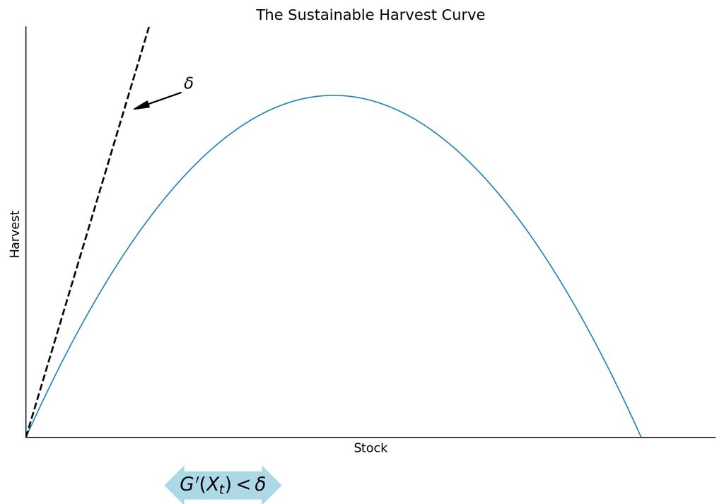